# Project 2

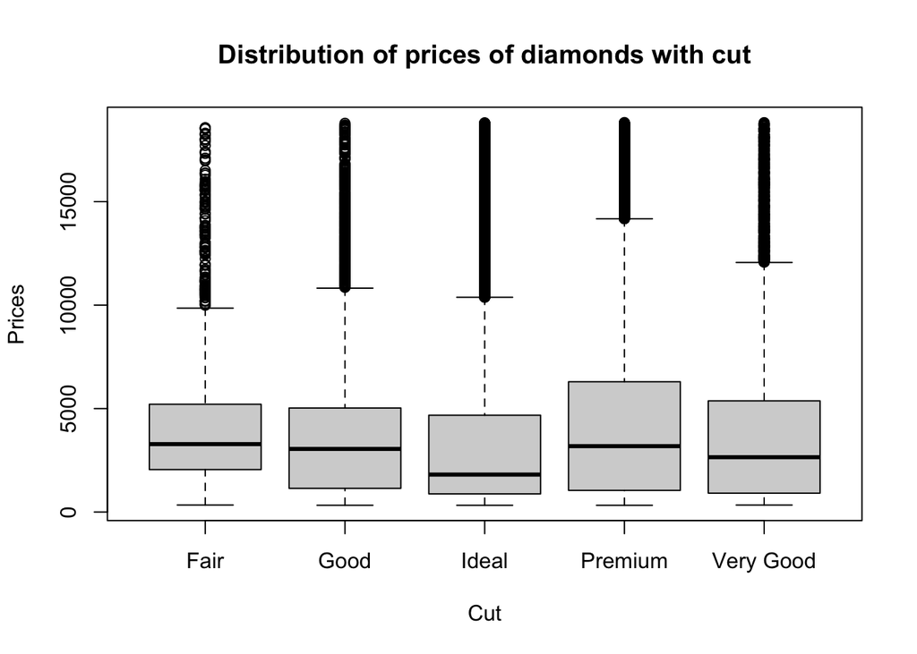

Boxplot for carat

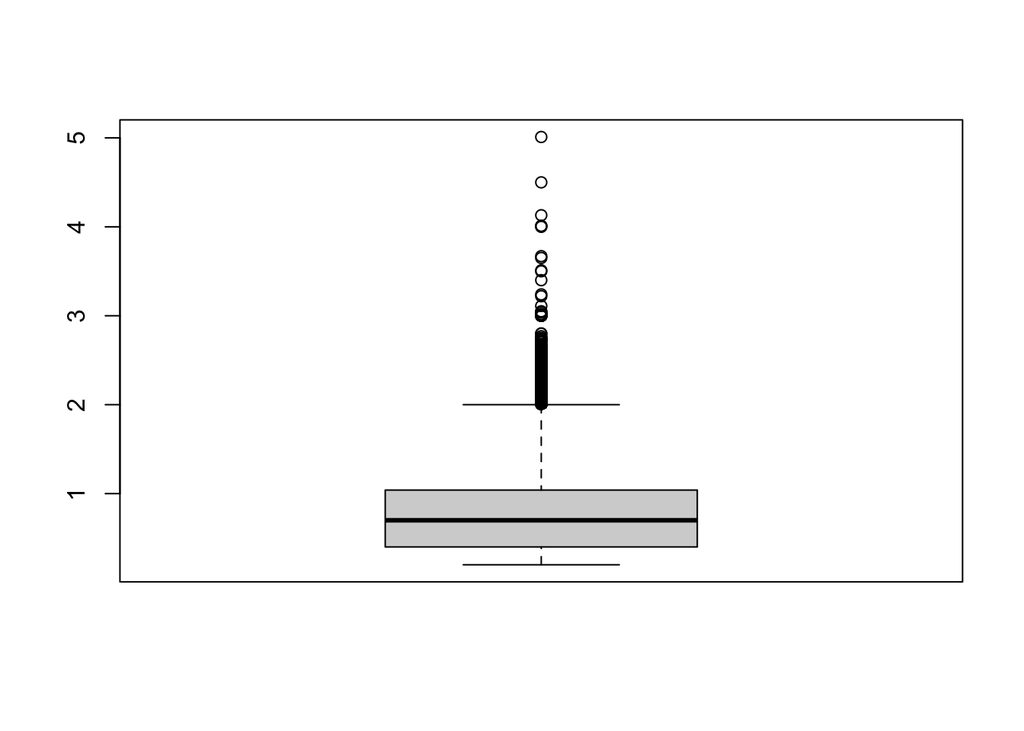

Boxplot for price

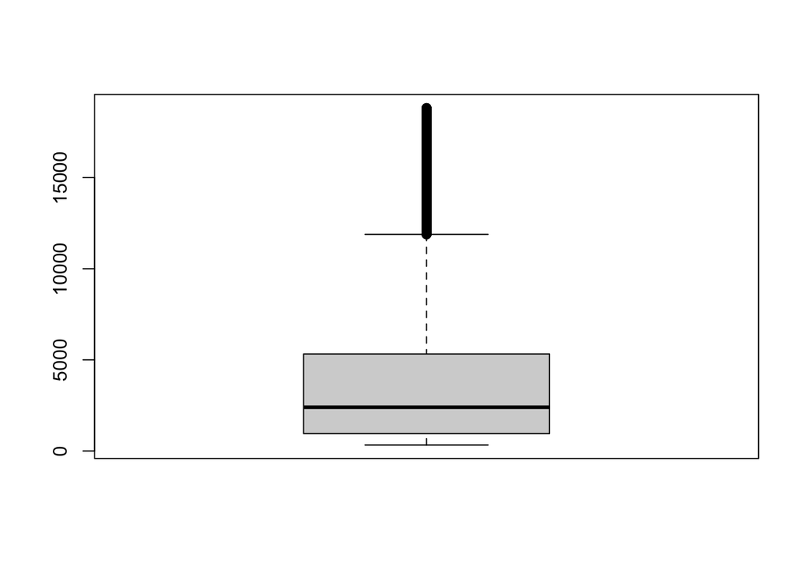

Boxplot for table and depth

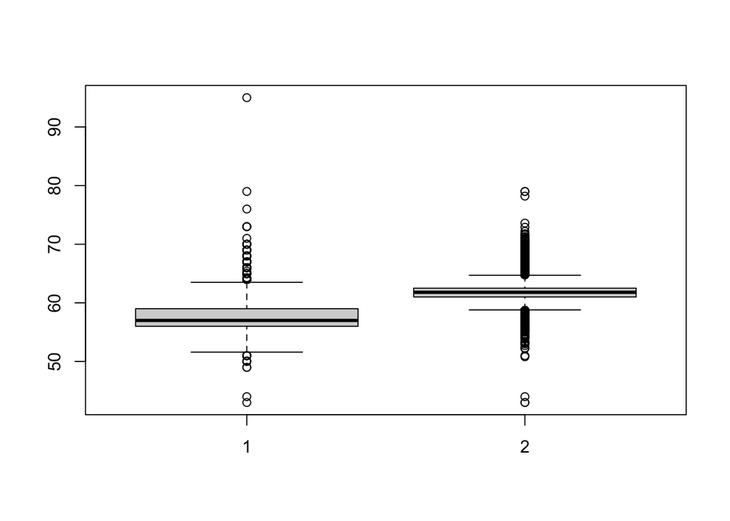

**Removing outlier**

```
##        X             carat               cut        color        clarity
##  Min.   :    1   Min.   :0.2000   Fair     : 1489   D: 6731   SI1    :12607
##  1st Qu.:13014   1st Qu.:0.3900   Good     : 4738   E: 9716   VS2    :11998
##  Median :27913   Median :0.7000   Ideal    :21078   F: 9421   SI2    : 8225
##  Mean   :27019   Mean   :0.7487   Premium  :13048   G:11052   VS1    : 8081
##  3rd Qu.:40924   3rd Qu.:1.0200   Very Good:11694   H: 7840   VVS2   : 5060
##  Max.   :53940   Max.   :2.0000                     I: 4863   VVS1   : 3650
##                                                     J: 2424   (Other): 2426
##      depth           table           price             x
##  Min.   :43.00   Min.   :43.00   Min.   :  326   Min.   :0.000
##  1st Qu.:61.10   1st Qu.:56.00   1st Qu.:  928   1st Qu.:4.690
##  Median :61.80   Median :57.00   Median : 2289   Median :5.650
##  Mean   :61.75   Mean   :57.43   Mean   : 3533   Mean   :5.639
##  3rd Qu.:62.50   3rd Qu.:59.00   3rd Qu.: 4958   3rd Qu.:6.480
##  Max.   :72.90   Max.   :79.00   Max.   :18818   Max.   :8.420
##
##        y                z
##  Min.   : 0.000   Min.   : 0.000
##  1st Qu.: 4.700   1st Qu.: 2.890
##  Median : 5.660   Median : 3.490
##  Mean   : 5.644   Mean   : 3.483
##  3rd Qu.: 6.470   3rd Qu.: 4.010
##  Max.   :58.900   Max.   :31.800
##
```

**Histogram**

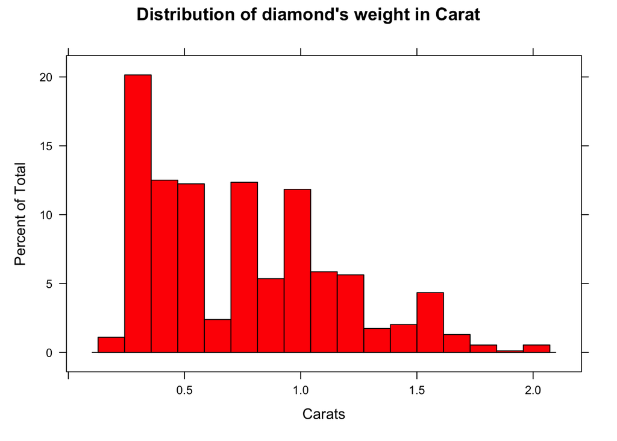

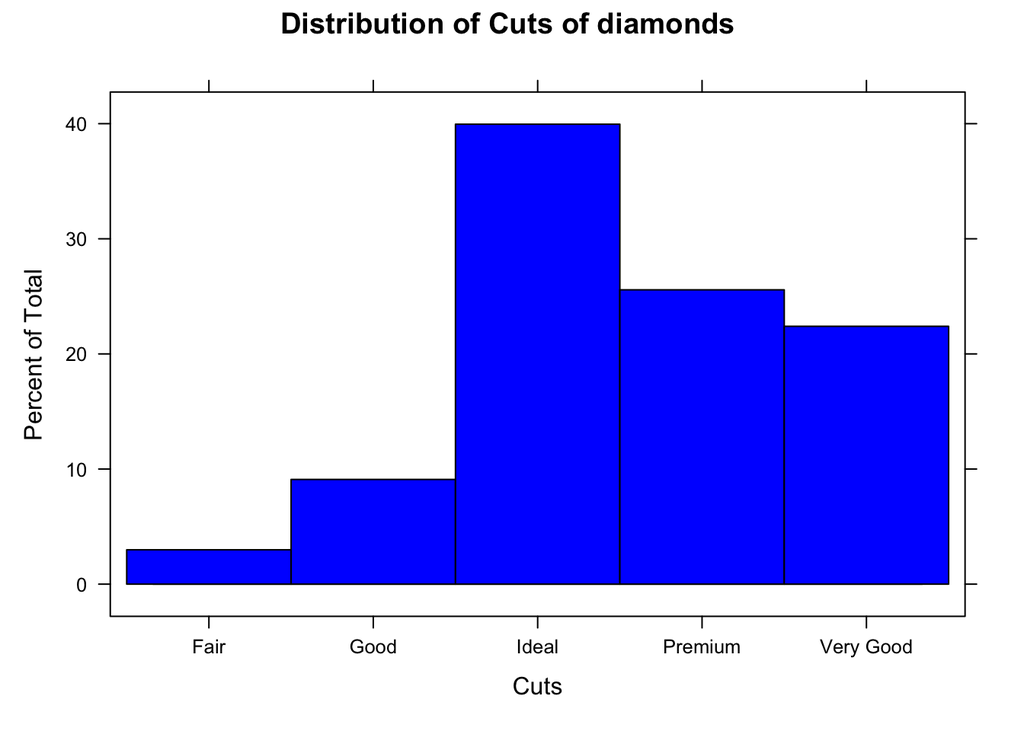

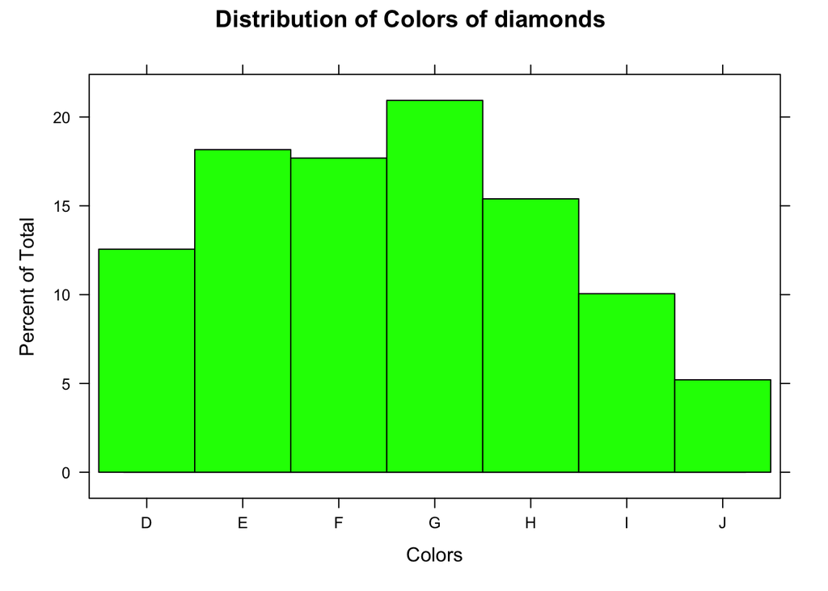

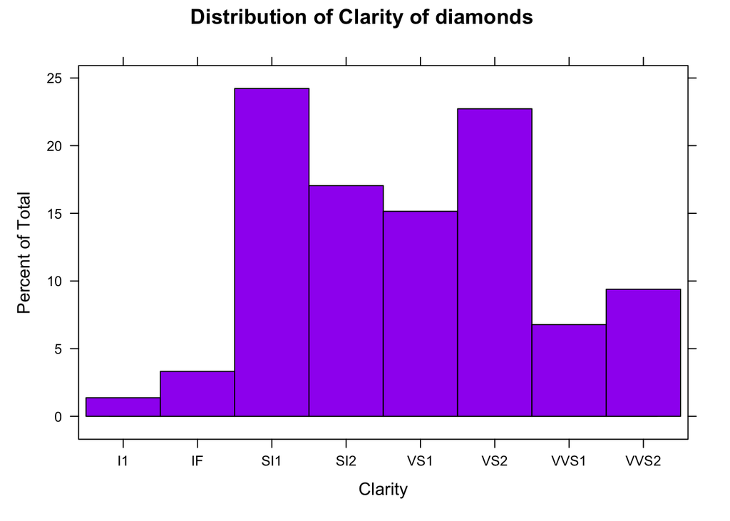

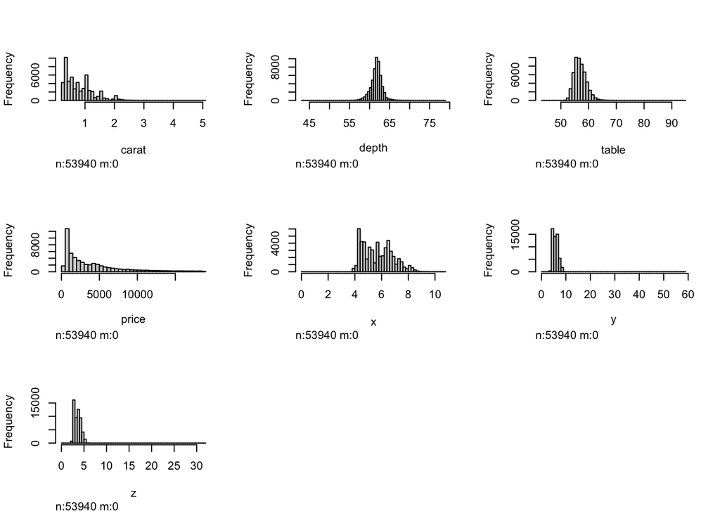

**Some other useful plots**

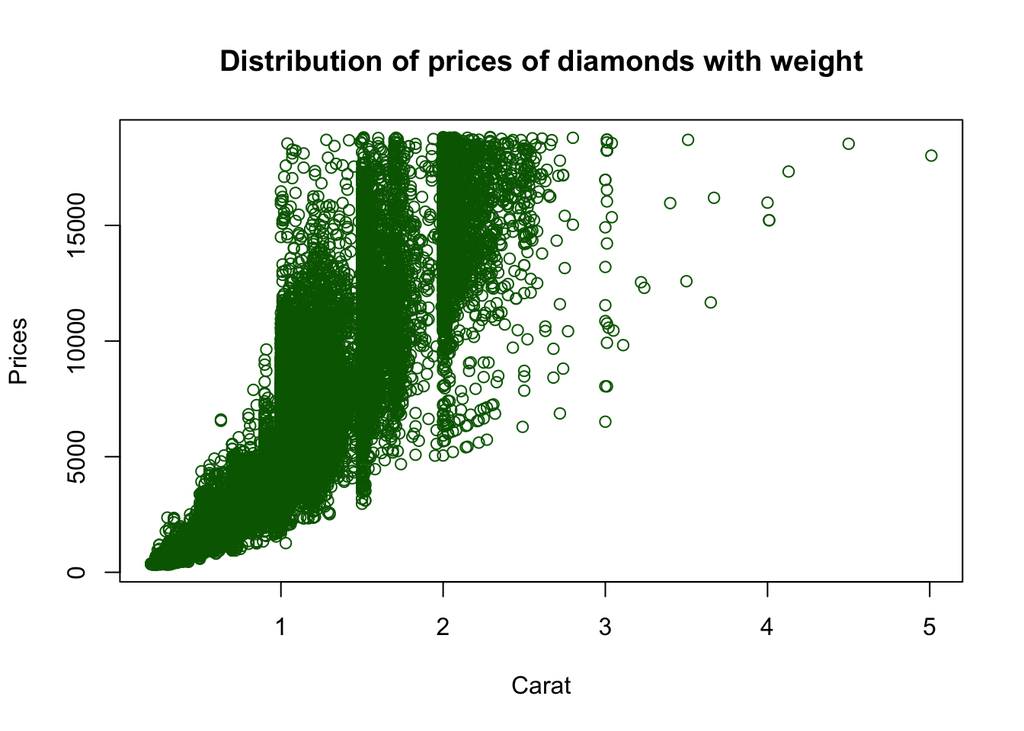

The scatter plot shows a strong positive correlation between carat and price. Low carat diamond denoted on x axis is mostly observed. It is clear that lower carat diamonds have lower price. As the carat size increases, we see diamond price increasing.

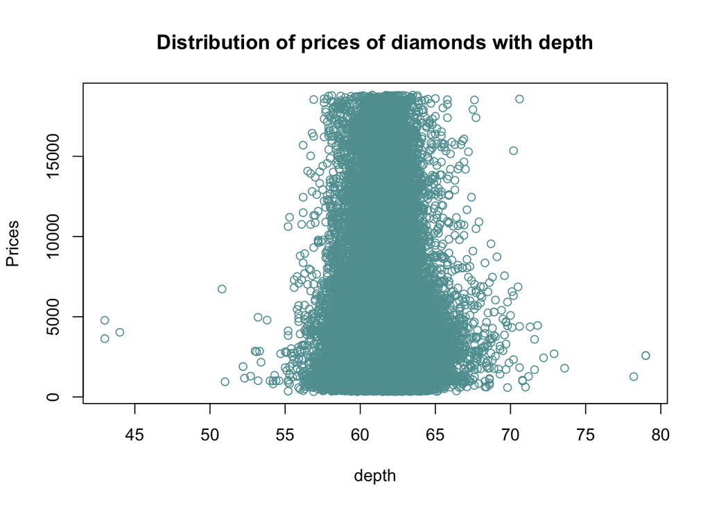

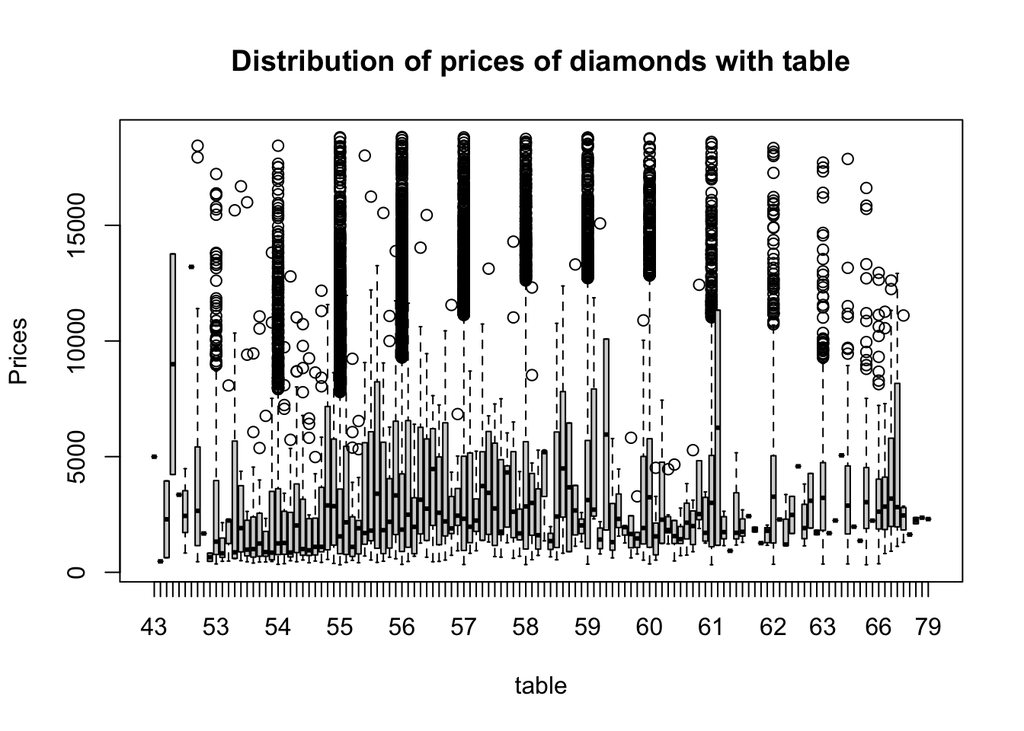

**Correlation**

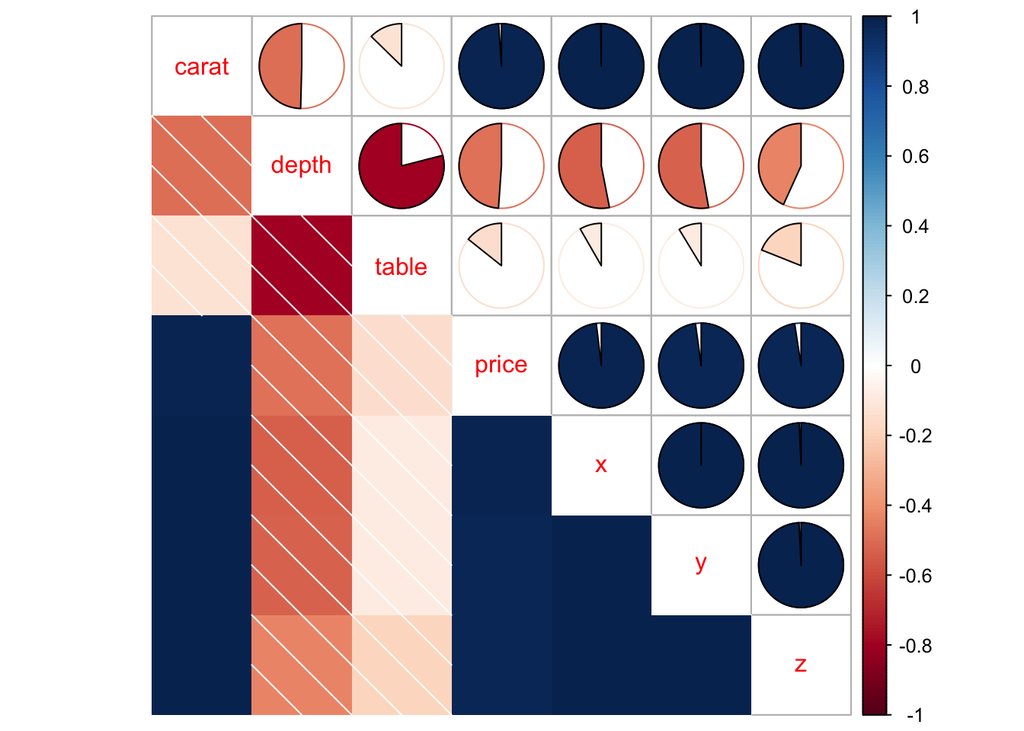

**Regression**

```
##
## Call:
## lm(formula = model, data = df.train)
##
## Residuals:
##      Min       1Q   Median       3Q      Max
## -21122.1   -594.9   -186.3    379.1   9940.1
##
## Coefficients:
##               Estimate Std. Error t value Pr(>|t|)
## (Intercept)   1836.851    478.927   3.835 0.000126 ***
## carat        11147.221     56.755 196.409  < 2e-16 ***
## cutGood        587.561     40.360  14.558  < 2e-16 ***
## cutIdeal       842.882     40.201  20.967  < 2e-16 ***
## cutPremium     775.275     38.757  20.003  < 2e-16 ***
## cutVery Good   739.713     38.796  19.067  < 2e-16 ***
## colorE        -207.314     21.592  -9.602  < 2e-16 ***
## colorF        -270.906     21.902 -12.369  < 2e-16 ***
## colorG        -459.181     21.426 -21.431  < 2e-16 ***
## colorH        -980.599     22.803 -43.004  < 2e-16 ***
## colorI       -1459.635     25.580 -57.063  < 2e-16 ***
## colorJ       -2376.769     31.376 -75.752  < 2e-16 ***
## clarityIF     5340.668     61.547  86.774  < 2e-16 ***
## claritySI1    3675.088     52.672  69.773  < 2e-16 ***
## claritySI2    2720.051     52.892  51.427  < 2e-16 ***
## clarityVS1    4587.151     53.747  85.347  < 2e-16 ***
## clarityVS2    4295.361     52.939  81.139  < 2e-16 ***
## clarityVVS1   5037.934     56.876  88.577  < 2e-16 ***
## clarityVVS2   4976.237     55.320  89.954  < 2e-16 ***
## depth          -62.699      5.260 -11.920  < 2e-16 ***
## table          -25.335      3.501  -7.237 4.66e-13 ***
## x             -962.172     35.602 -27.026  < 2e-16 ***
## y               -2.280     19.560  -0.117 0.907187
## z              -29.828     34.754  -0.858 0.390763
## ---
## Signif. codes:  0 '***' 0.001 '**' 0.01 '*' 0.05 '.' 0.1 ' ' 1
##
## Residual standard error: 1137 on 37734 degrees of freedom
## Multiple R-squared:  0.9196, Adjusted R-squared:  0.9196
## F-statistic: 1.877e+04 on 23 and 37734 DF,  p-value: < 2.2e-16
```

```
##
## Call:
## lm(formula = price ~ ., data = df.train)
##
## Residuals:
##      Min       1Q   Median       3Q      Max
## -21114.8   -603.9   -176.7    384.8   9912.4
##
## Coefficients:
##                Estimate Std. Error t value Pr(>|t|)
## (Intercept)   1.032e+03  4.814e+02   2.144    0.032 *
## X             5.680e-03  4.157e-04  13.665  < 2e-16 ***
## carat         1.107e+04  5.688e+01 194.659  < 2e-16 ***
## cutGood       6.036e+02  4.028e+01  14.985  < 2e-16 ***
## cutIdeal      8.512e+02  4.011e+01  21.224  < 2e-16 ***
## cutPremium    7.866e+02  3.867e+01  20.342  < 2e-16 ***
## cutVery Good  7.550e+02  3.872e+01  19.500  < 2e-16 ***
## colorE       -2.105e+02  2.154e+01  -9.774  < 2e-16 ***
## colorF       -2.732e+02  2.185e+01 -12.502  < 2e-16 ***
## colorG       -4.622e+02  2.137e+01 -21.622  < 2e-16 ***
## colorH       -9.759e+02  2.275e+01 -42.897  < 2e-16 ***
## colorI       -1.463e+03  2.552e+01 -57.343  < 2e-16 ***
## colorJ       -2.380e+03  3.130e+01 -76.050  < 2e-16 ***
## clarityIF     5.336e+03  6.140e+01  86.902  < 2e-16 ***
## claritySI1    3.680e+03  5.254e+01  70.032  < 2e-16 ***
## claritySI2    2.734e+03  5.277e+01  51.807  < 2e-16 ***
## clarityVS1    4.591e+03  5.362e+01  85.627  < 2e-16 ***
## clarityVS2    4.298e+03  5.281e+01  81.379  < 2e-16 ***
## clarityVVS1   5.036e+03  5.674e+01  88.763  < 2e-16 ***
## clarityVVS2   4.973e+03  5.518e+01  90.113  < 2e-16 ***
## depth        -5.793e+01  5.259e+00 -11.016  < 2e-16 ***
## table        -2.437e+01  3.493e+00  -6.978 3.05e-12 ***
## x            -9.030e+02  3.578e+01 -25.240  < 2e-16 ***
## y            -8.811e-01  1.951e+01  -0.045    0.964
## z            -2.966e+01  3.467e+01  -0.856    0.392
## ---
## Signif. codes:  0 '***' 0.001 '**' 0.01 '*' 0.05 '.' 0.1 ' ' 1
##
## Residual standard error: 1134 on 37733 degrees of freedom
## Multiple R-squared:   0.92,  Adjusted R-squared:   0.92
## F-statistic: 1.809e+04 on 24 and 37733 DF,  p-value: < 2.2e-16
```

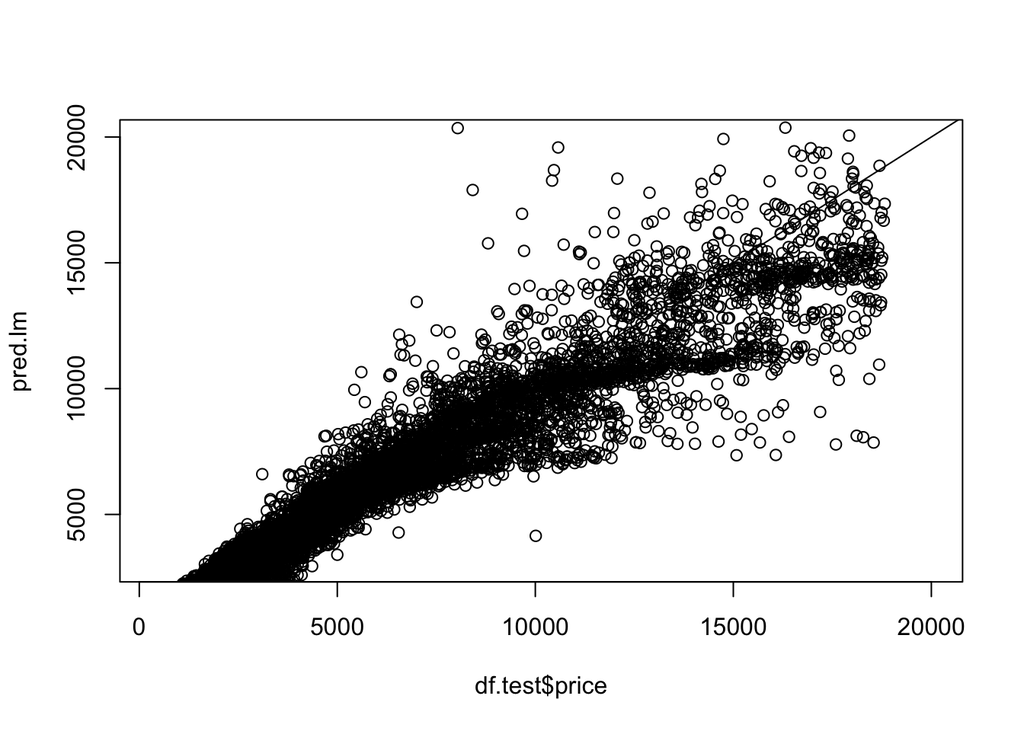

I feel that the data deviates after 13000 otherwise more or less linear.

```
##              GVIF Df GVIF^(1/(2*Df))
## X        1.223916  1        1.106307
## carat   21.537981  1        4.640903
## cut      1.932928  4        1.085868
## color    1.182831  6        1.014091
## clarity  1.350773  7        1.021709
## depth    1.683869  1        1.297640
## table    1.778181  1        1.333484
## x       47.619022  1        6.900654
## y       14.983402  1        3.870840
## z       17.943180  1        4.235939
```